# BACS_HW5

106022113

## Problem 1 : Verify Google DOI apps

### (a) : Probability of a random app that is malicious

```r
prob <- dnorm(-3.7,0,1)
paste("The probability of apps being malicious is: ", prob)
```

```
## [1] "The probability of apps being malicious is:  0.000424780270550751"
```

Since the binomial distribution is considered approximately to be normal, we can just use the function *dnorm* to get the probability.

### (b) : How many apps are malicious in 2.2 million?

```r
paste("Approximately ",round(prob*2.2*10^6)," apps are malicious in 2.2 million apps.")
```

```
## [1] "Approximately  935  apps are malicious in 2.2 million apps."
```

## Problem 2 : Verizon Repairing Phones

```r
data <- read.csv("verizon.csv")
head(data)
```

```
##    Time Group
## 1 17.50  ILEC
## 2  2.40  ILEC
## 3  0.00  ILEC
## 4  0.65  ILEC
## 5 22.23  ILEC
## 6  1.20  ILEC
```

### (a) : NULL Distribution of t-values

#### i. Visualize distribution and marking the mean

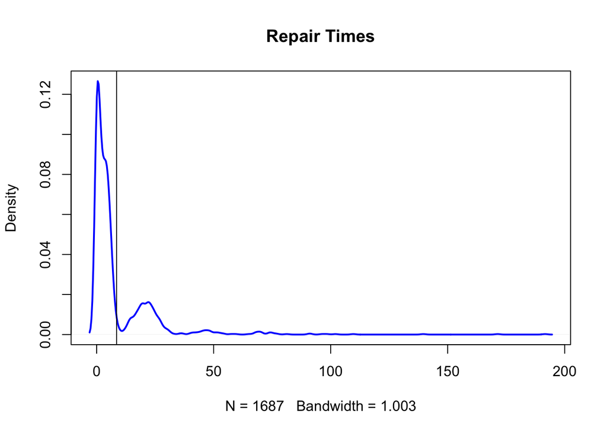

```r
times <- data$Time
plot(density(times), col="blue", lwd=2,main = "Repair Times")
abline(v = mean(times))
```

#### ii. Testing Hypothesis

Since Verizon claims that the repair time is 7.6 minutes, we can set $H0 = 7.6 minutes$, and then we have $H1 \neq 7.6 minutes$

#### iii. Estimate Population Mean and 99% confidence interval

Population mean can be estimated from the sample mean and the confidence interval can be found using the equation below.
$$\mu \pm z_{0.995}\frac{\sigma}{\sqrt{n}}$$
However, this equation assumes the distribution is normal since it uses a factor calculated from normal distribution percentile. Hence, the best way to estimate the confidence intervals is by using quantile.

```r
#ci2_99 <- quantile(times,probs = c(0.005,0.995))
conf1 <- mean(times)-(qnorm(0.995,0,1)*sd(times)/sqrt(length(times)))
conf2 <- mean(times)+(qnorm(0.995,0,1)*sd(times)/sqrt(length(times)))
paste("Population Mean: ",mean(times),", 99% Confidence interval:(",conf1,",",conf2,")")
```

```
## [1] "Population Mean:  8.52200948429164 , 99% Confidence interval:( 7.59457509656072 , 9.44944387202256 )"
```

#### iv. Find t-value, p-value using statistics measures

We can have the t-value with the equation below and then derive p-value from it.
$$t = \frac{\overline{x}-\mu_0}{\frac{s}{\sqrt{n}}}$$

```r
t <- (mean(times)-7.6)/(sd(times)/sqrt(length(times)))
p <- 1-pt(t,length(times)-1)
paste("t-statistic: ",t, ", p-value: ",p)
```

```
## [1] "t-statistic:  2.56076233446444 , p-value:  0.00526534229428899"
```

#### v. Describe these values to NULL Distribution

The t-statistic is the ratio of the difference of the estimated value from its hypothesized value to its standard error. It will give us the answer if the hypothesis is true or it lacks further evidence. The p-value is the probability that the results from your sample data occurred by chance.

#### vi. Conclusions of the test

Since the p-value is $0.0053 < 0.01$, we can arrive at the conclusion that we are confident to reject the null hypothesis. Because our stats indicate that we have covered 1-0.0053 percentage of the distribution, which is more than 99%.

### (b) Using bootstrapping on the sample data:

#### i. 99% CI of Bootstrapped means

```r
sample_statistic <- function(stat_func, sample0){
  resample <- sample(sample0, length(sample0),replace = TRUE)
  stat_func(resample)
}
sample_means <- replicate(length(times),sample_statistic(mean,times))
#Confidence Interval:
ci_99 <- quantile(sample_means, probs = c(0.005,0.995))
paste("The confidence interval is: ",ci_99[1],",",ci_99[2])
```

```
## [1] "The confidence interval is:  7.66434688796681 , 9.46541019561351"
```

#### ii. 99% CI of Bootstrapped difference between means

```r
boot_mean_diffs <- function(sample0, hyp){
  resample <- sample(sample0, length(sample0),replace = TRUE)
  return(mean(resample)-hyp)
}
mean_diffs <- replicate(length(times),boot_mean_diffs(times,7.6))
#Confidence Interval
ci1_99 <- quantile(mean_diffs,c(0.005,0.995))
paste("The confidence interval is: ",ci1_99[1],",",ci1_99[2])
```

```
## [1] "The confidence interval is:  0.0195534084173092 , 1.8534385299348"
```

#### iii. 99% CI of Bootstrapped t-intervals

```r
boot_t_stat <- function(sample0, hyp){
  resample <- sample(sample0, length(sample0), replace = TRUE)
  diff <- mean(resample)- hyp
  se <- sd(resample)/sqrt(length(resample))
  return (diff/se)
}
t_boots <- replicate(length(times), boot_t_stat(times,7.6))
t_ci_99 <- quantile(t_boots, probs = c(0.005,0.995))
paste("The confidence interval is: ",t_ci_99[1],",",t_ci_99[2])
```

```
## [1] "The confidence interval is:  0.355314536023217 , 4.54309472054522"
```

#### iv. Plots of above

i.Percentile

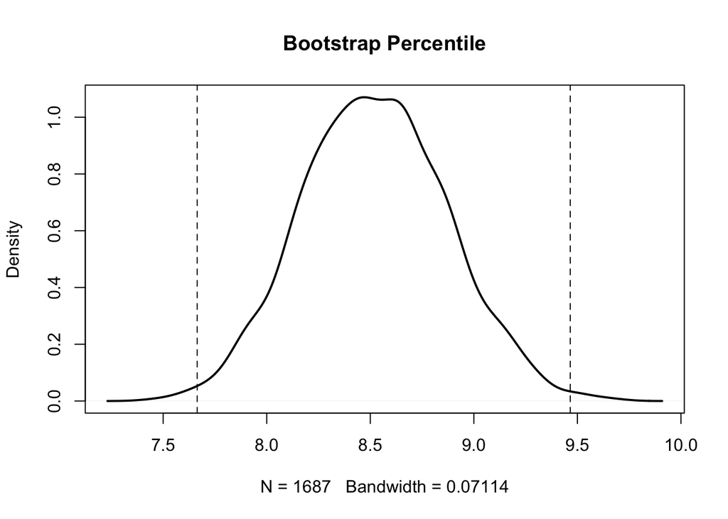

```r
plot(density(sample_means),lwd =2, main = "Bootstrap Percentile")
abline(v = ci_99,lty = "dashed")
```

2. Difference of Means

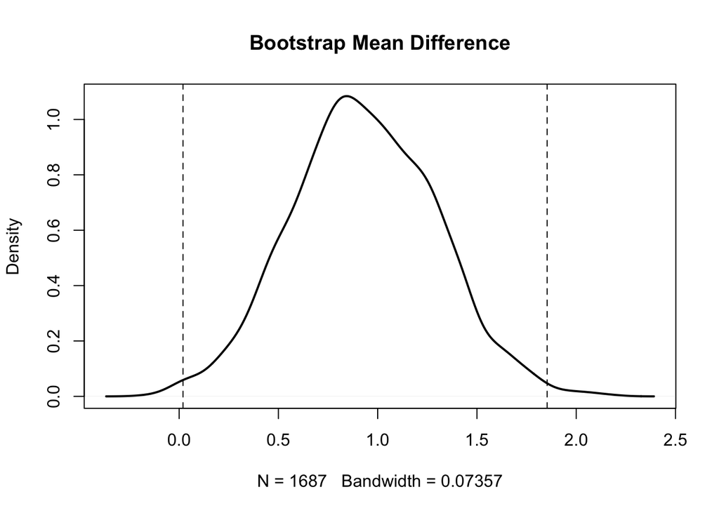

```r
plot(density(mean_diffs),lwd =2, main = "Bootstrap Mean Difference")
abline(v = ci1_99,lty = "dashed")
```

3. Bootstrapped t-interval

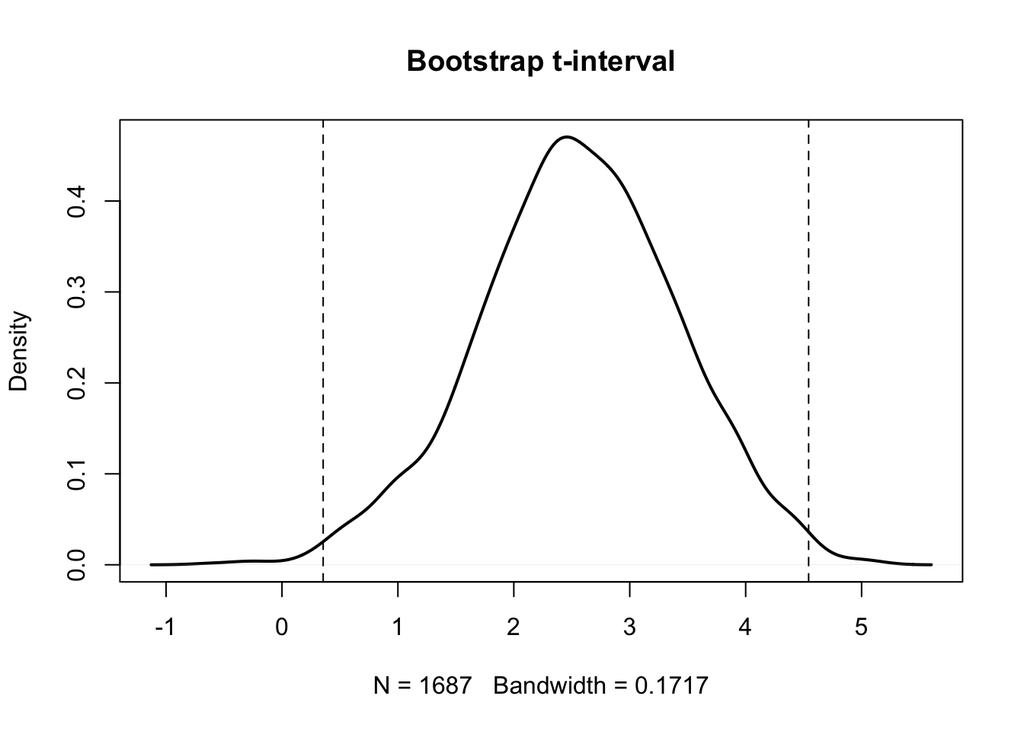

```r
plot(density(t_boots),lwd =2, main = "Bootstrap t-interval")
abline(v = t_ci_99,lty = "dashed")
```